# Introduction to RNA-seq analysis

From FASTQ files to biology, step by step

Morteza Sabri

October 2026

## The question

**What does dexamethasone do to airway smooth muscle cells?**

- Dexamethasone: a glucocorticoid, the standard anti-inflammatory drug in asthma
- Airway smooth muscle (ASM) cells from **4 donors**
- Each donor’s cells: **untreated** and **treated** (1 µM, 18 h)
- Total: 8 RNA-seq samples, paired-end Illumina reads

Himes *et al.* (2014) *PLoS One* 9:e99625, GEO GSE52778. Bioconductor package: `airway`.

| sample | donor | condition |
| --- | --- | --- |
| SRR1039508 | N61311 | untreated |
| SRR1039509 | N61311 | dexamethasone |
| SRR1039512 | N052611 | untreated |
| SRR1039513 | N052611 | dexamethasone |
| SRR1039516 | N080611 | untreated |
| SRR1039517 | N080611 | dexamethasone |
| SRR1039520 | N061011 | untreated |
| SRR1039521 | N061011 | dexamethasone |

## The road map

|  | Step | Tool | Output |
| --- | --- | --- | --- |
| **upstream** | 0. get the reference (once) | `curl` from HISAT2 and Ensembl | genome index, gene annotation |
|  | 1. get reads | `curl` from ENA | FASTQ |
|  | 2. quality control | FastQC, MultiQC | HTML reports |
|  | 3. trim | Trimmomatic | cleaner FASTQ |
|  | 4. align to the genome | HISAT2, samtools | BAM |
|  | 5. count reads per gene | featureCounts (or Salmon) | **count matrix** |
| **downstream** | 6. explore | DESeq2 (VST, PCA) | plots |
|  | 7. differential expression | DESeq2 (+ edgeR) | gene table |
|  | 8. interpretation | clusterProfiler, DOSE, ReactomePA | GO, pathways, diseases |

Every step is one script in the repository; `./run_all.sh` runs all of them and builds these slides.

# Upstream: from reads to counts

## A read in a FASTQ file

@SRR1039508.1 HWI-ST177:290:C0TECACXX:1:1101:1225:2130/1 ← read name  
CATTGCTGATACCAANNNNNNNNGCATTCCTCAAGGTCTTCCTCCTTCCCTTACGGAATTACA ← the bases  
+  
HJJJJJJJJJJJJJJ########00?GHIJJJJJJJIJJJJJJJJJJJJJJJJJHHHFFFFFD ← one quality letter per base

| Part of the name | Meaning |
| --- | --- |
| `SRR1039508` | run in the public archive (SRA/ENA): donor N61311, untreated |
| `.1` | pair number in the file: the first read pair |
| `HWI-ST177` | instrument ID (an Illumina HiSeq 2000) |
| `290` | run number on that instrument |
| `C0TECACXX` | flow cell ID |
| `1` | lane on the flow cell |
| `1101` | tile: one imaged patch of the lane |
| `1225:2130` | X and Y position of the cluster on the tile |
| `/1` | read 1 of the pair; its mate in the R2 file ends in `/2` |

- Quality letter = Phred score **Q** = −10 · log<sub>10</sub>(error probability)
- `J` = Q41 (1 error in ~12,000), `#` = Q2: the 8 `N`s were unreadable
- This is read 1 of the first sample, not hand-picked: 8 bases unreadable. Rare (0.4% of reads), but QC and trimming exist for exactly this: trimming dropped this read.

## Get the reads, check their quality

```bash
# 1. get reads: stream the run's 2 files from ENA,
#    keep the first 2 M reads (4 lines per read)
curl -sL $URL_R1 | gzip -dc | head -n 8000000 | gzip > R1.fq.gz
curl -sL $URL_R2 | gzip -dc | head -n 8000000 | gzip > R2.fq.gz
```

```bash
# 2. quality control: one report
#    per file, MultiQC merges them
fastqc R1.fq.gz R2.fq.gz
multiqc .
```

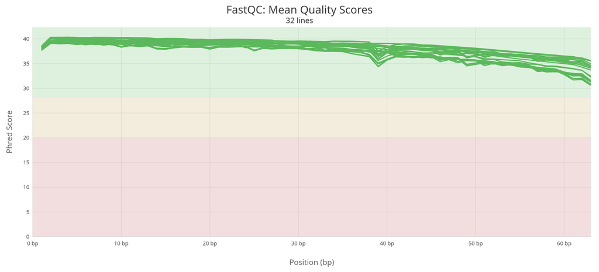

Mean quality along the read, every FASTQ file (raw and trimmed). Green = good. The 16 ENA URLs are in `config/samples.tsv`.

## Trim, align, count

```bash
# 0. once: index the human genome (GRCh38)
#    (we download this index prebuilt: 8 files, 4 GB)
hisat2-build genome.fa grch38/genome

# 3. trim: cut low-quality ends, drop short reads
trimmomatic PE R1.fq.gz R2.fq.gz \
  R1_trimmed.fq.gz R1_unpaired.fq.gz \
  R2_trimmed.fq.gz R2_unpaired.fq.gz \
  ILLUMINACLIP:TruSeq3-PE-2.fa:2:30:10:2:True \
  SLIDINGWINDOW:4:20 MINLEN:25

# 4. align (splice-aware), sort, index
hisat2 -x grch38/genome \
  -1 R1_trimmed.fq.gz -2 R2_trimmed.fq.gz |
  samtools sort -o sample.bam
samtools index sample.bam

# 5. count read pairs per gene
featureCounts -p --countReadPairs -s 0 \
  -a Homo_sapiens.GRCh38.gtf.gz \
  -o counts.txt *.bam
```

`grch38/genome` = the index files’ shared name (`genome.1.ht2` … `genome.8.ht2`). The GTF is Ensembl’s gene annotation: where each gene and exon lies on the genome.

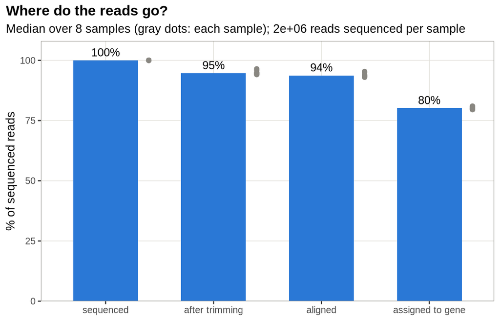

Of 2,000,000 read pairs per sample, 95% survive trimming, 94% align, 80% land in a gene.

## The reads already tell the story

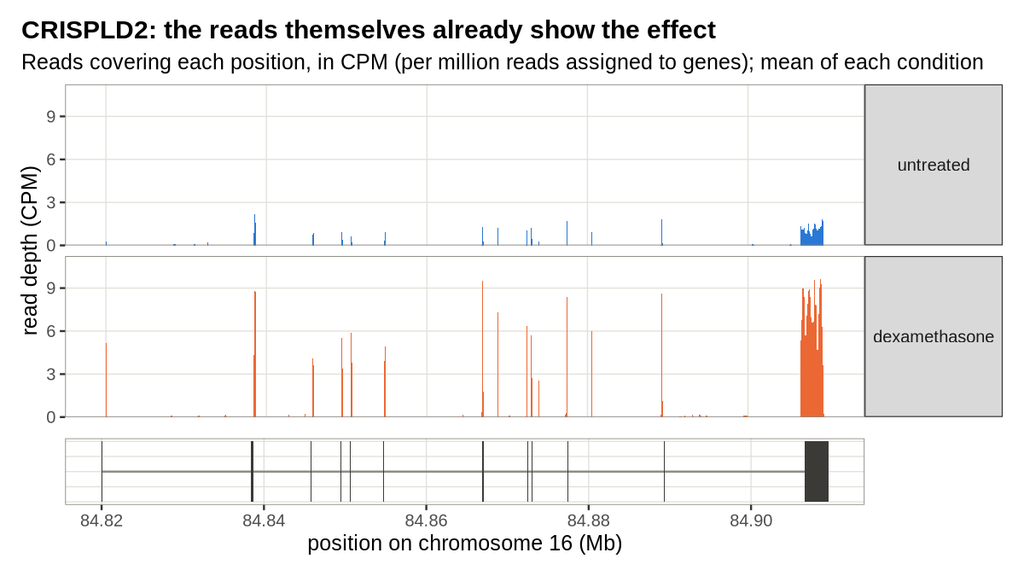

CRISPLD2, the gene highlighted in the original paper. Height = CPM. Blocks below = exons: reads pile up there because RNA is spliced.

## The count matrix, and a second route

|  | untreated N61311 | treated N61311 | untreated N052611 | treated N052611 |
| --- | --- | --- | --- | --- |
| GPX3 | 74 | 1,487 | 235 | 2,732 |
| SAMHD1 | 151 | 1,607 | 146 | 2,257 |
| ADAMTS1 | 561 | 3,374 | 967 | 4,081 |
| CXCL12 | 4,671 | 997 | 1,950 | 586 |
| ACTB | 4,809 | 7,034 | 5,766 | 9,123 |

One row per gene (78,941 in the annotation), one column per sample (2 of 4 donors shown): **raw counts**, not normalized. This table is the input for everything downstream.

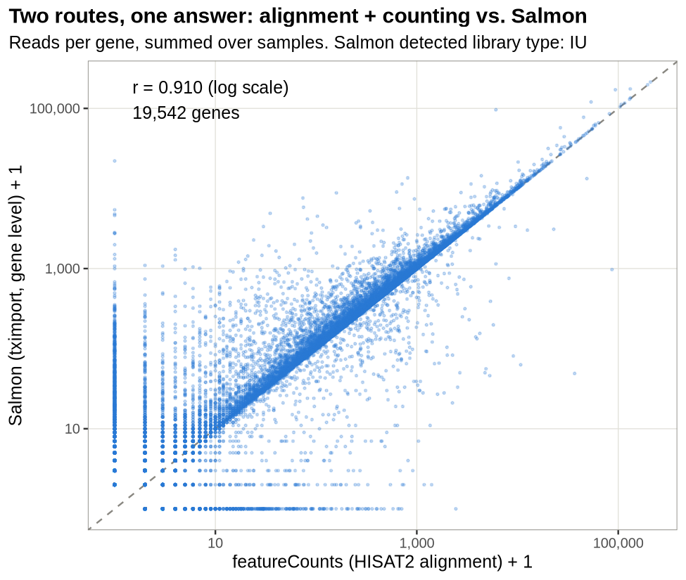

**Salmon** skips alignment: it maps reads to transcript sequences and estimates counts in seconds.

## Choosing the upstream tools

| Tool | What it does | Pick it when | Trade-off |
| --- | --- | --- | --- |
| **STAR** | aligns reads to the genome, across splice junctions | you need new splice junctions, fusions or variants; large projects (ENCODE, TCGA) | ~32 GB RAM for a human genome |
| **HISAT2** (used here) | the same job, with a compact index | memory is limited: a laptop, a course, a small server | ~8 GB RAM |
| **featureCounts** (used here) or HTSeq-count | counts aligned reads per gene, from the BAM | gene-level differential expression; simple and transparent | reads that fit several genes are dropped |
| **Salmon** or kallisto (Salmon used here as a check) | skips the genome: matches reads to known transcripts and estimates counts | you only need expression: many samples, little time, isoforms | no BAM to look at; finds no new genes, junctions or variants |

Need to **see the reads** or find something new (coverage, new splice junctions, variants)? Align. Need **counts**, even per known isoform? Salmon is enough. Many pipelines do both: nf-core/rnaseq aligns with STAR and counts with Salmon.

Here: HISAT2 + featureCounts fit a laptop and give the BAM behind the coverage plot; Salmon checks the counts.

# Downstream: from counts to genes

## Normalization: comparing samples fairly

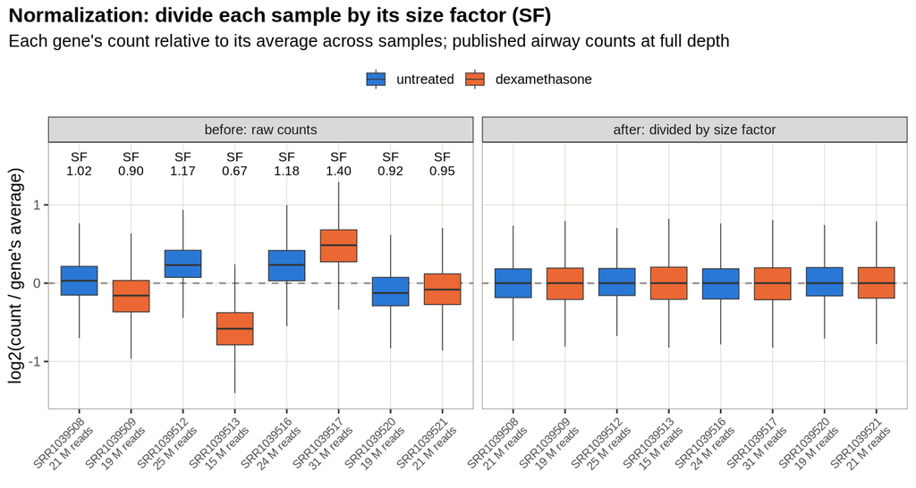

Depths differ (here 15–31 M reads). **Size factor** = median of a sample’s ratios to the gene averages; DESeq2 divides by it. Most genes don’t change between samples, so how far a sample’s typical gene sits from average tells us its sequencing depth, and we divide that out.

## Do the samples group by treatment?

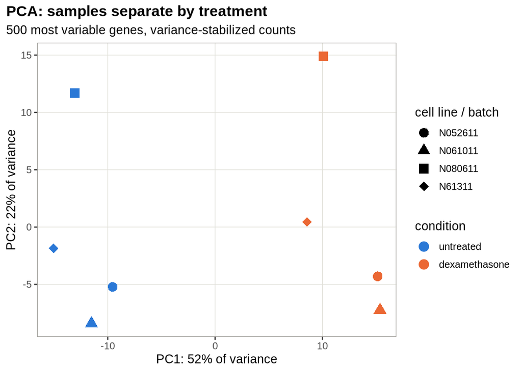

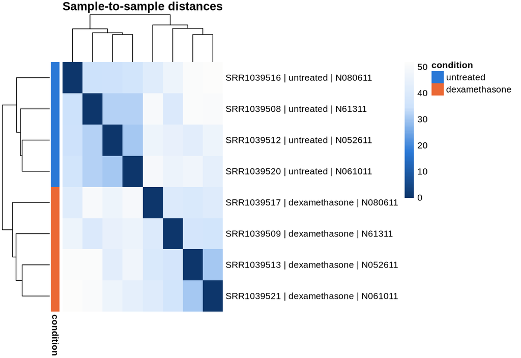

PC1 = treatment. PC2 = one donor that differs from the others.

## The model: DESeq2

```r
dds <- DESeqDataSetFromMatrix(
  countData = counts,
  colData   = samples,
  design    = ~ batch + condition)
dds <- DESeq(dds)
res <- results(dds, contrast =
  c("condition", "dexamethasone", "untreated"))
```

- Counts ~ negative binomial (overdispersed Poisson)
- `~ batch + condition`: compare treated vs. untreated **within each donor**
- 10,385 genes tested, **1,045** with FDR < 0.05
- 235 up, 154 down by more than 2-fold

| gene | mean count | log2 FC | adj. p |
| --- | --- | --- | --- |
| GPX3 | 994.5 | 3.701 | 6.5e-99 |
| SAMHD1 | 1,028.0 | 3.680 | 4.6e-97 |
| ADAMTS1 | 2,408.6 | 2.266 | 5.9e-66 |
| CXCL12 | 2,289.0 | -1.941 | 2.1e-54 |
| FKBP5 | 206.0 | 3.799 | 2.9e-54 |
| DUSP1 | 266.1 | 2.892 | 1.5e-53 |
| MAOA | 192.2 | 3.159 | 4.3e-46 |
| NEXN | 442.0 | 1.961 | 4.4e-43 |
| CRISPLD2 | 240.3 | 2.648 | 1.4e-40 |
| SORT1 | 437.3 | 2.027 | 1.4e-39 |

## All genes at once: MA and volcano plots

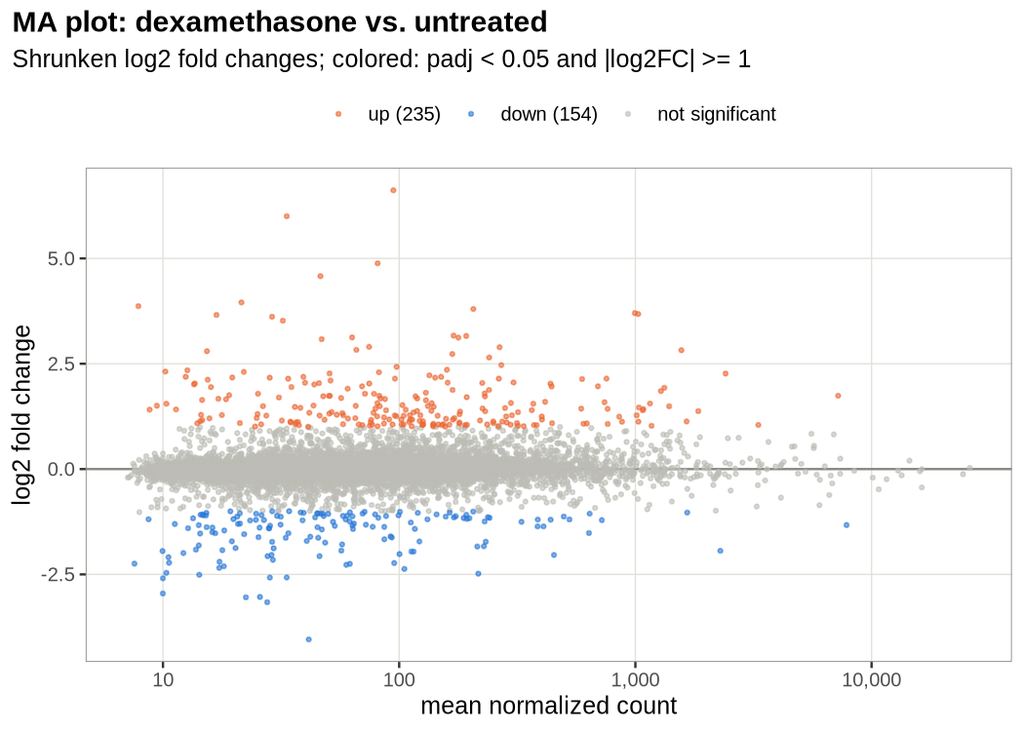

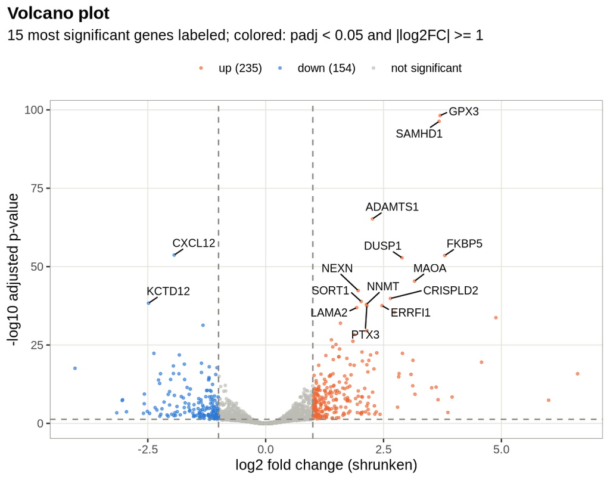

We shrink fold changes so that genes with few reads can’t show large changes they don’t have evidence for.

## Gene by gene

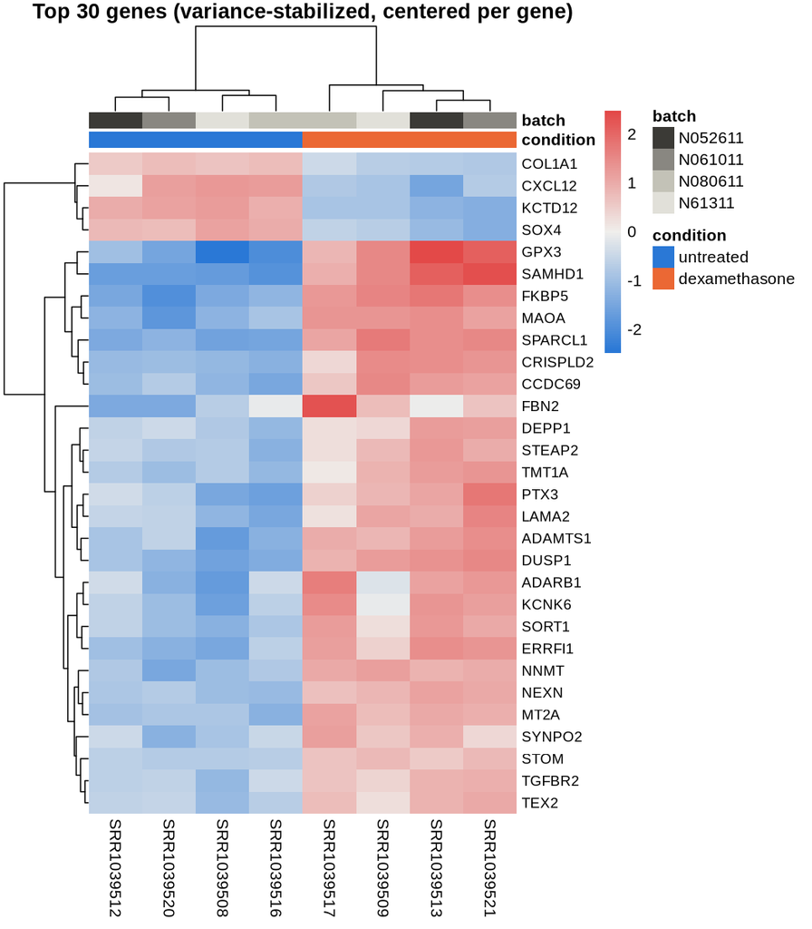

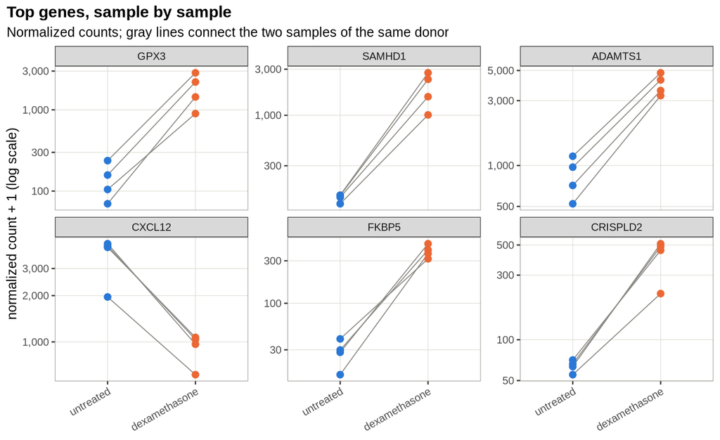

## Is 2 million reads per sample enough?

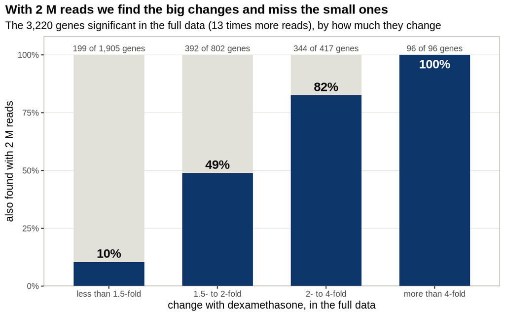

Each bar: genes that the full published data calls significant, grouped by how much they change. Dark = also found with our 2 M reads. Finding small changes takes more reads, or more samples.

# From genes to biology

## Two ways to ask “what do these genes do?”

### Over-representation (ORA)

1. Take the significant genes
2. For each gene set (GO term, pathway): more of its genes in the list than expected?
3. Hypergeometric / Fisher’s test against the **universe** of tested genes

```r
enrichGO(sig_genes, universe = tested_genes,
         OrgDb = org.Hs.eg.db, ont = "BP")
```

### Gene set enrichment (GSEA)

1. Rank **all** genes from most up to most down
2. Do a set’s genes cluster at the top or bottom?
3. No cutoff needed; catches many small shifts

```r
gseGO(ranked_genes,
      OrgDb = org.Hs.eg.db, ont = "BP")
```

Same idea for every database: GO (functions), KEGG / Reactome / WikiPathways (pathways), Disease Ontology (diseases).

## Gene Ontology: over-represented terms

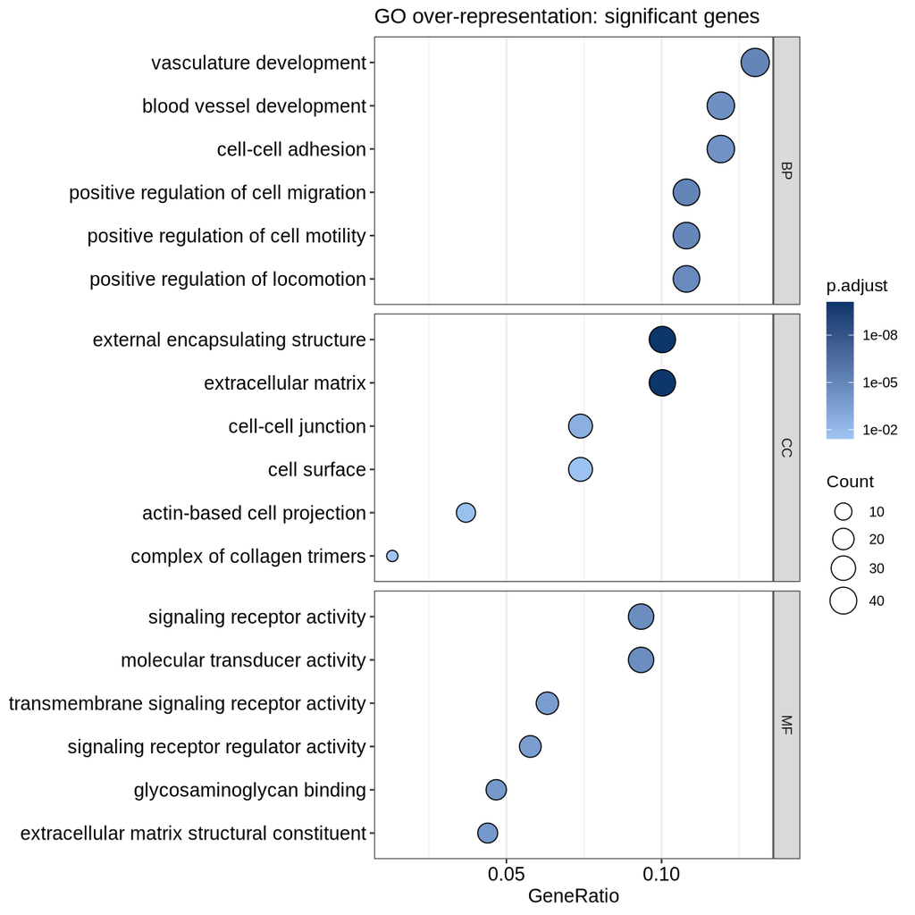

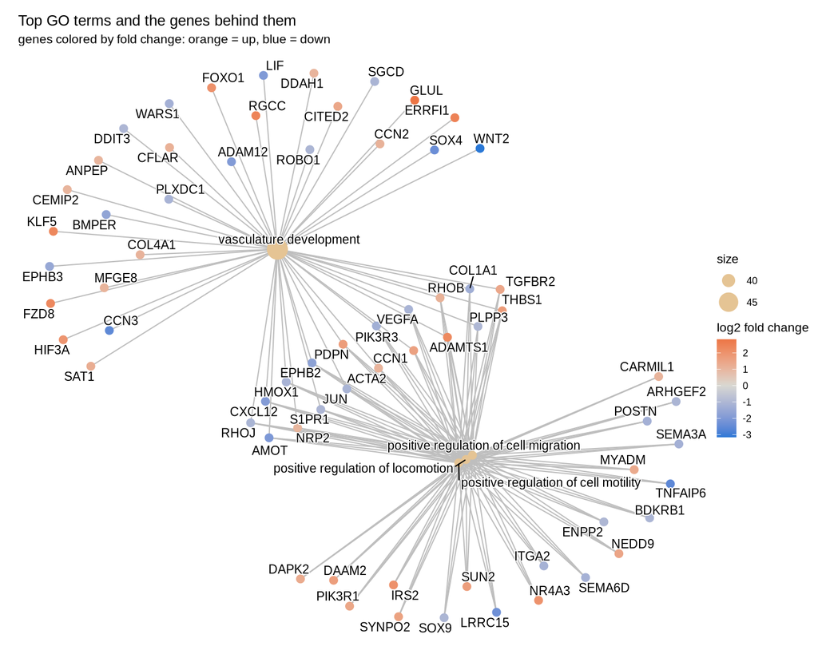

## Too many terms? Group them

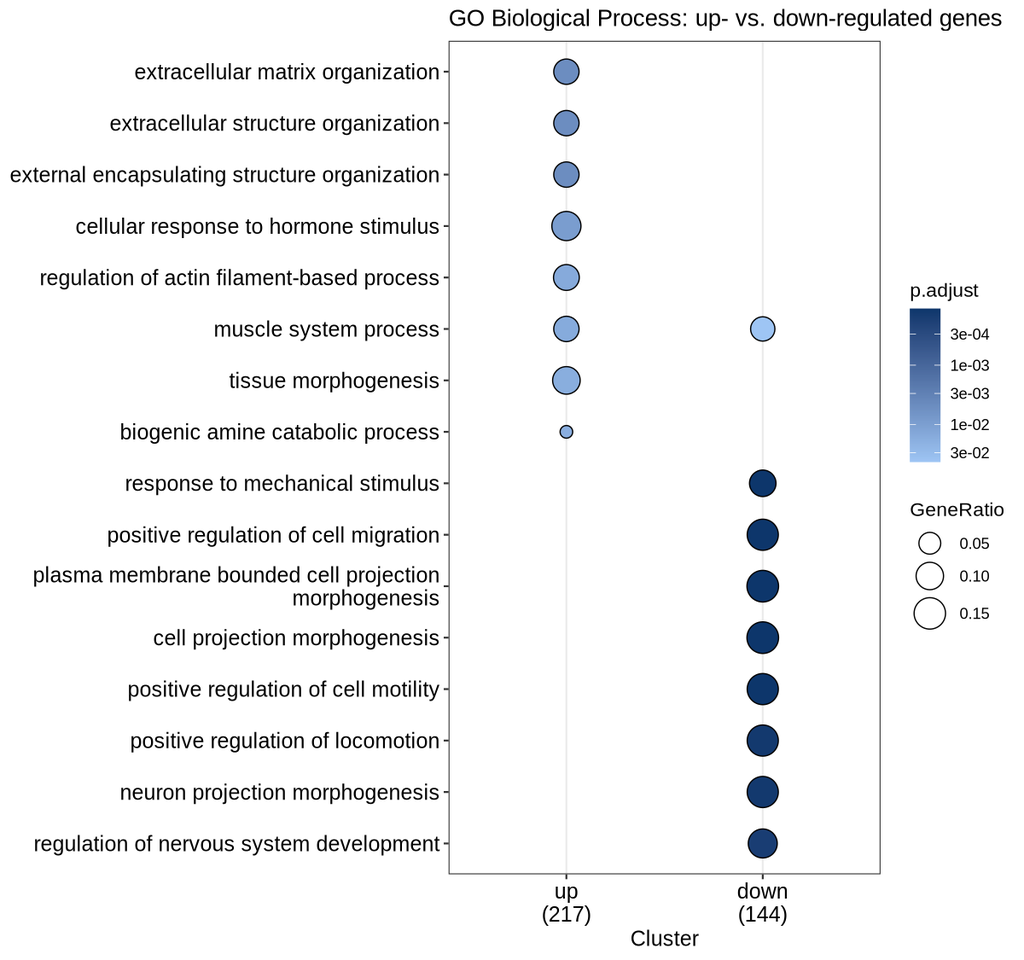

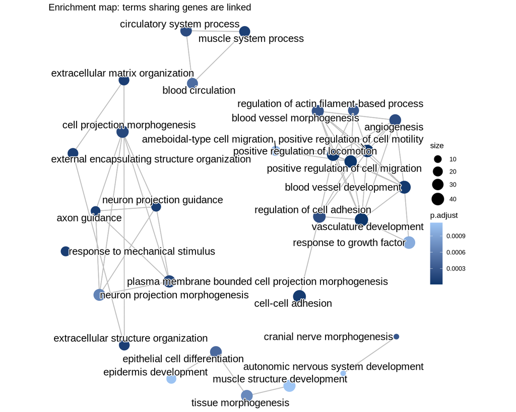

Left: up- and down-regulated genes tested separately. Right: terms that share genes are linked and form themes.

## GSEA: whole ranking, no cutoff

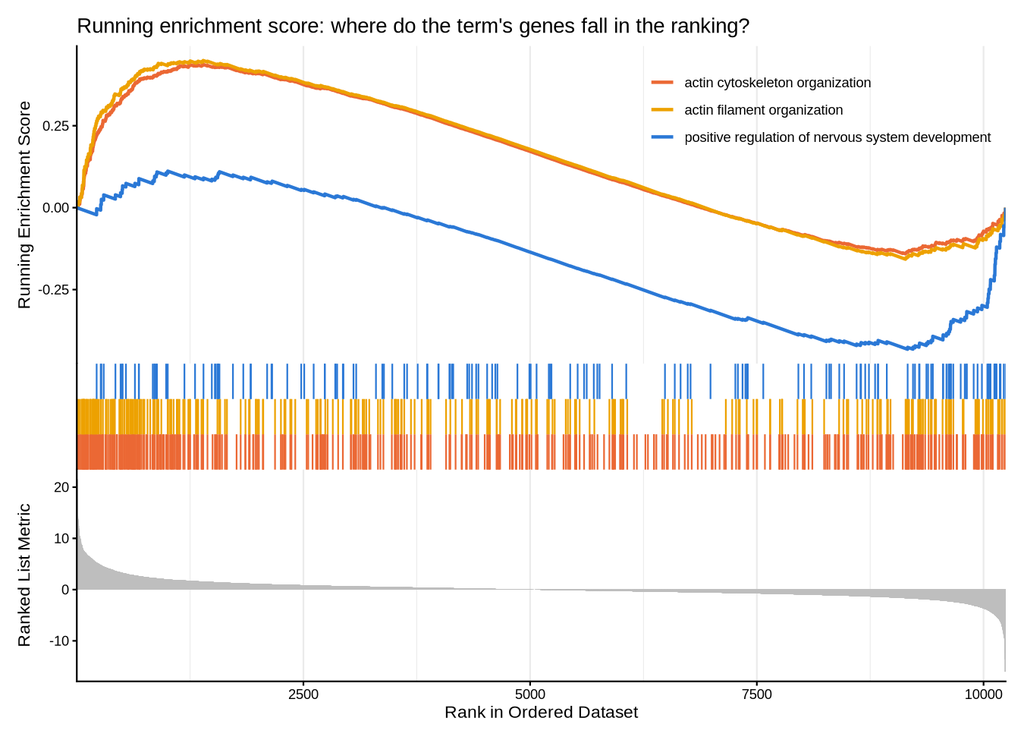

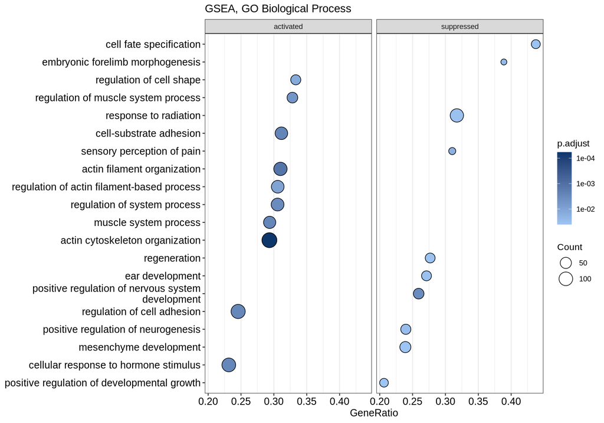

**ORA** finds processes where many genes change strongly, in either direction; **GSEA** finds processes where many genes shift a little in the same direction; where both agree, that’s the strongest result.

## Pathways: KEGG

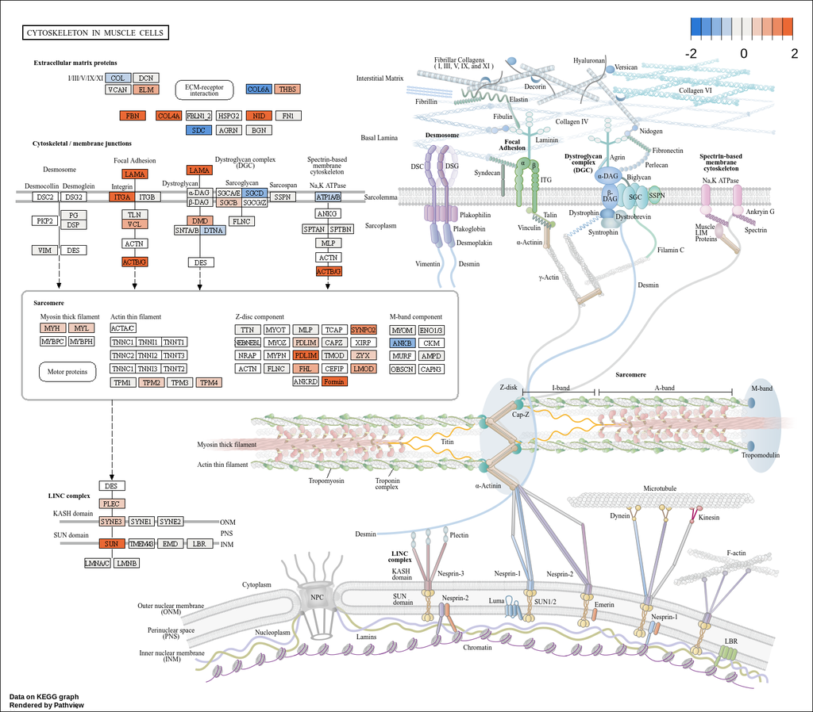

The most significant KEGG pathway, drawn as a map.

Each gene box is colored by its fold change: orange = up, blue = down with dexamethasone.

Maps and tables: folder `7_enriched_path`

## Pathways: Reactome and WikiPathways

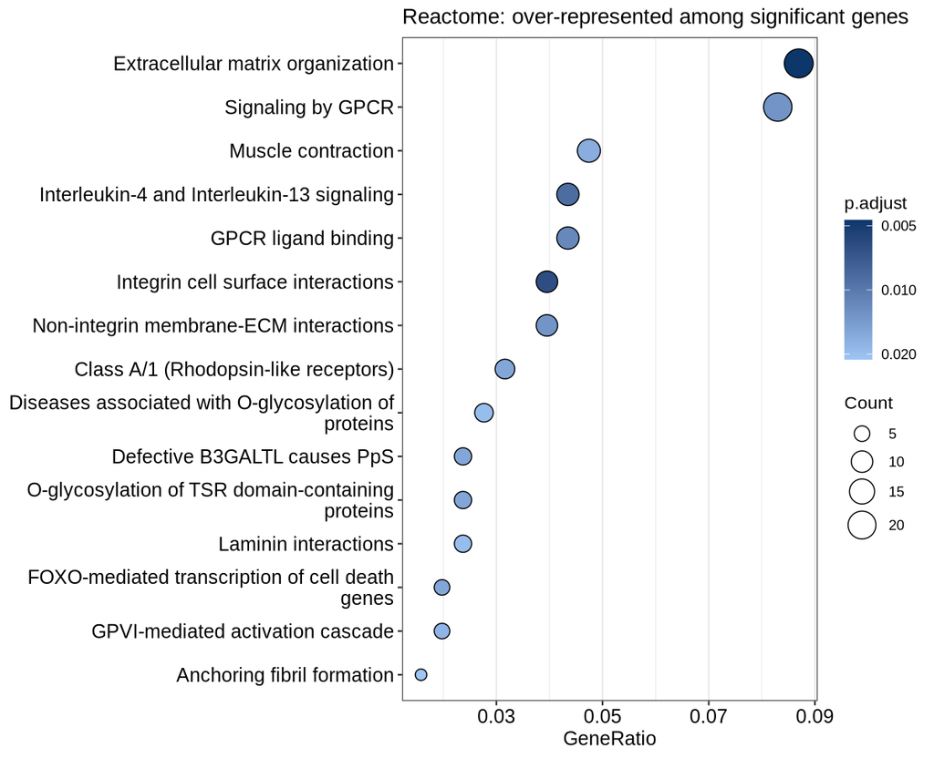

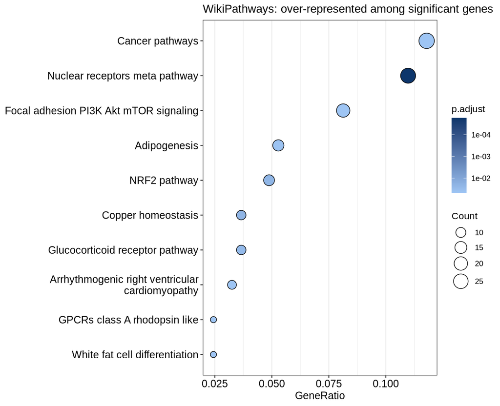

## Diseases and literature

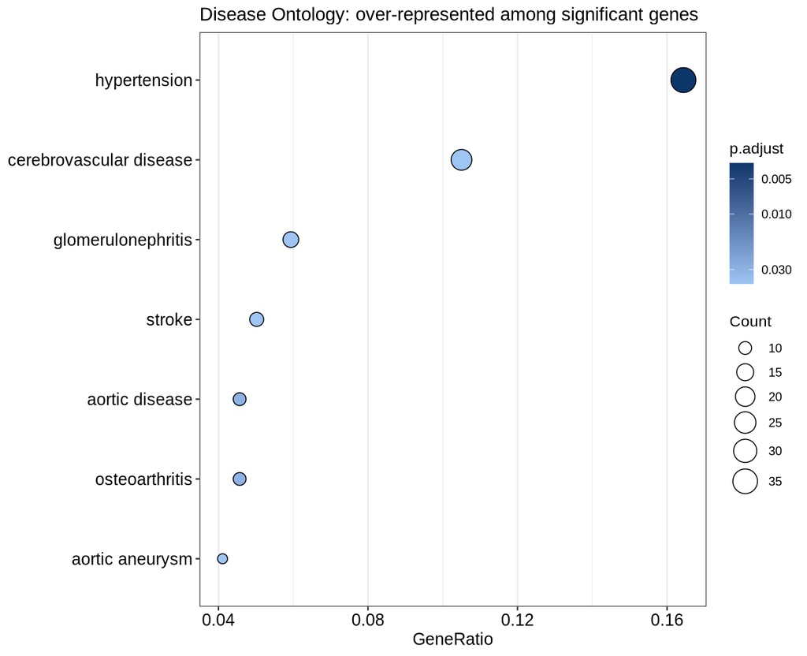

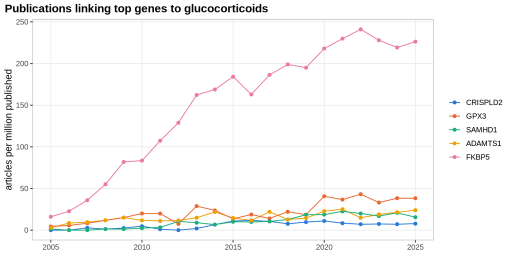

Left: Disease Ontology terms linked to the significant genes. Right: how often the top genes appear together with glucocorticoids in the literature (Europe PMC).

## Take-home messages

- **Design decides everything**: replicates, pairing, balanced batches. No pipeline fixes a confounded design.
- **Look before you test**: QC reports, PCA, sample distances.
- **Raw counts in, normalization inside the model**; account for batch / donor in the design.
- **FDR, not p-value**; shrunken fold changes for ranking and plots.
- **Enrichment is a summary, not a proof**: right universe, many redundant terms, database bias.
- **Depth buys power**: 2,000,000 read pairs per sample found the strong effects; the full data found 3× more significant genes.

## Run it yourself

```bash
git clone https://github.com/mortezasabri/rnaseq-workshop.git && cd rnaseq-workshop
micromamba env create -f environment.yml && micromamba activate rnaseq-workshop
./run_all.sh --dry-run     # checks tools, packages, sample sheet
./run_all.sh               # FASTQ -> results -> these slides (~15 min + one-time 6 GB download)

COUNTS_SOURCE=airway ./run_all.sh downstream   # laptop-only: skip upstream, use published counts
```

- One script per step: `upstream/01_download.sh` … `downstream/12_ReactomePA.R`
- Own data: copy `config/samples.template.tsv`, fill it in, `SAMPLES=config/my_samples.tsv ./run_all.sh`
- Further reading: the DESeq2 RNA-seq workflow (`rnaseqGene`), the clusterProfiler book

# Backup slides

## p-value histogram

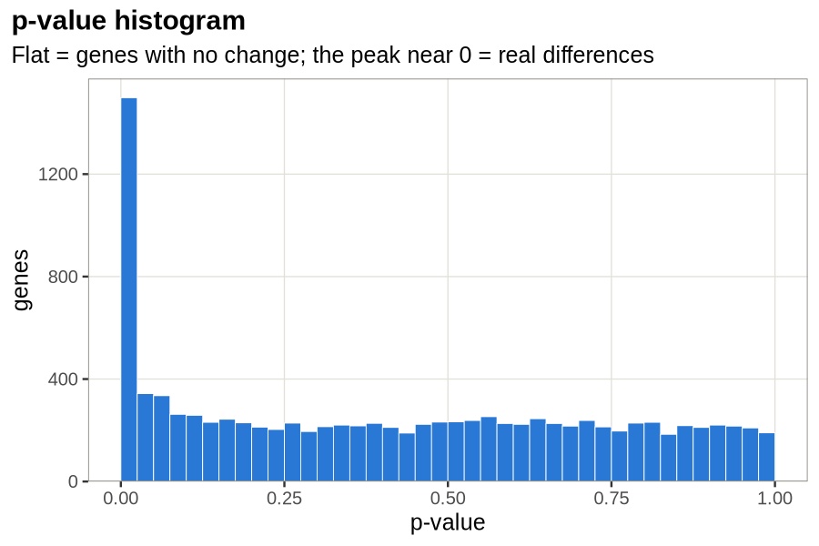

## Fold changes: plain vs. shrunken

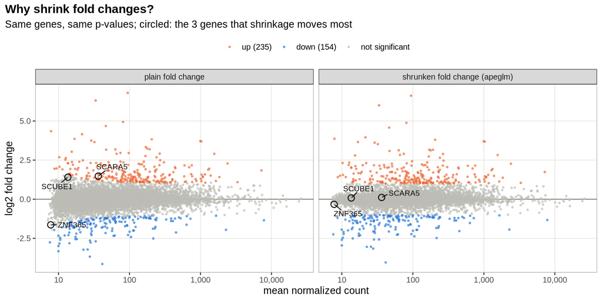

Left: plain fold changes; genes with few reads (left side) spread wide by chance. Right: after shrinkage they are pulled toward 0 unless the data support them. p-values are the same in both.

## DESeq2 vs. edgeR

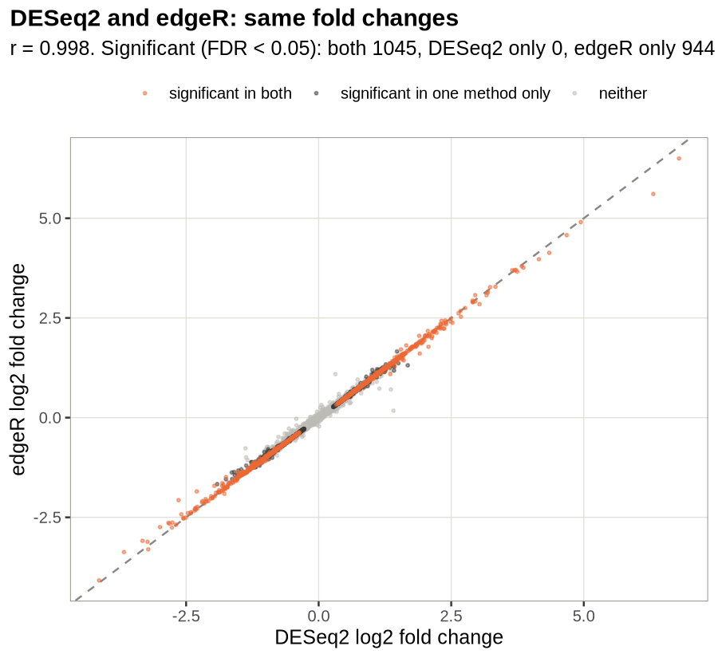

Same fold changes, different strictness. Significant genes: DESeq2 1,045, edgeR 1,989, in both 1,045 (every DESeq2 gene).

## GO terms: redundancy removed

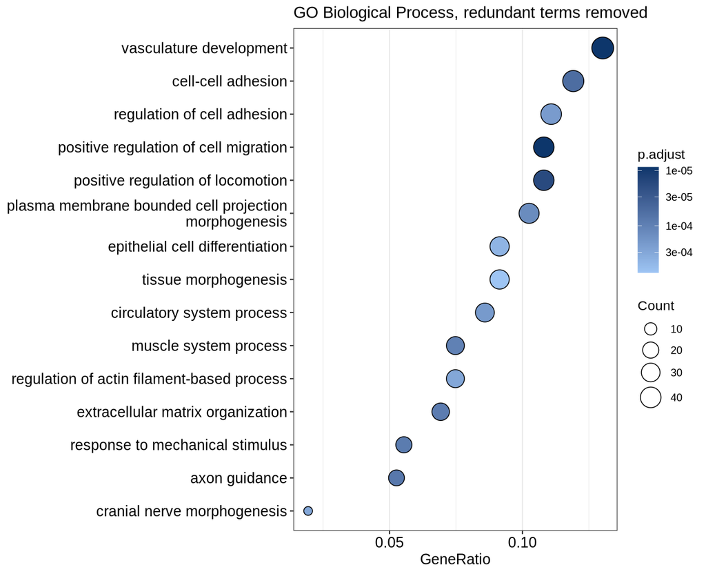

## GO terms clustered into themes

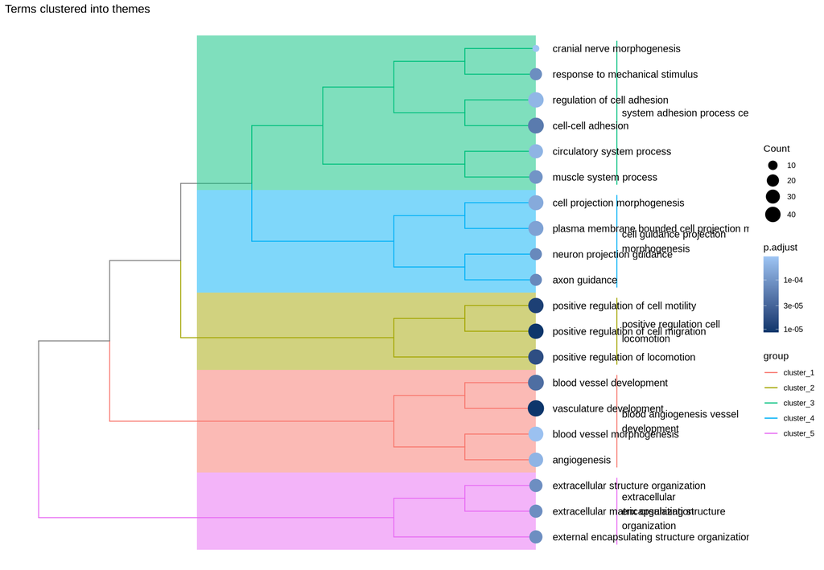

## GSEA: core-gene distributions

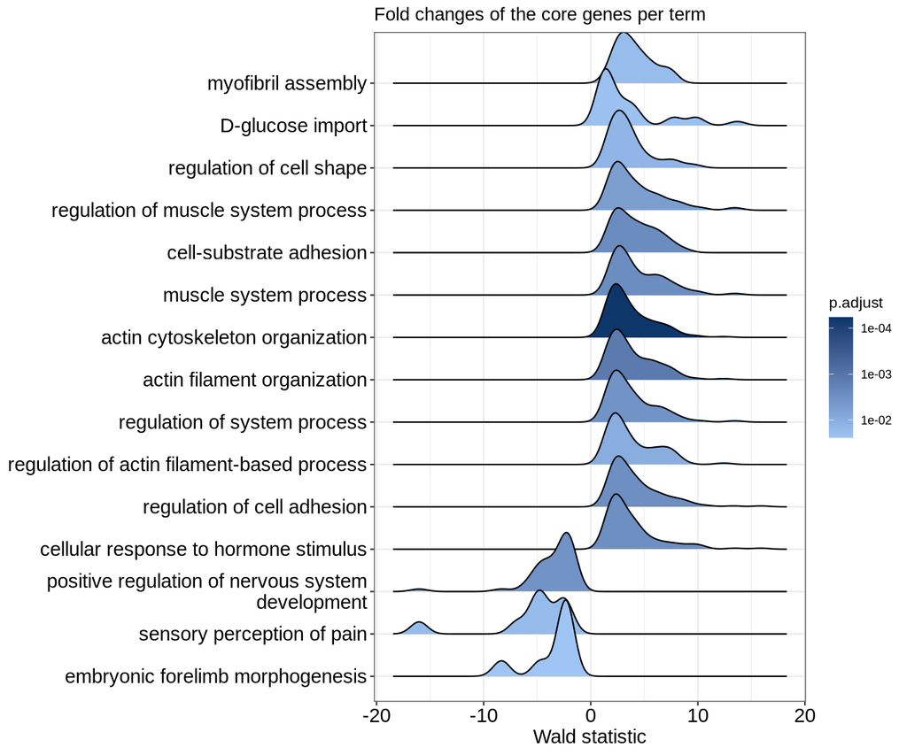

## KEGG: GSEA

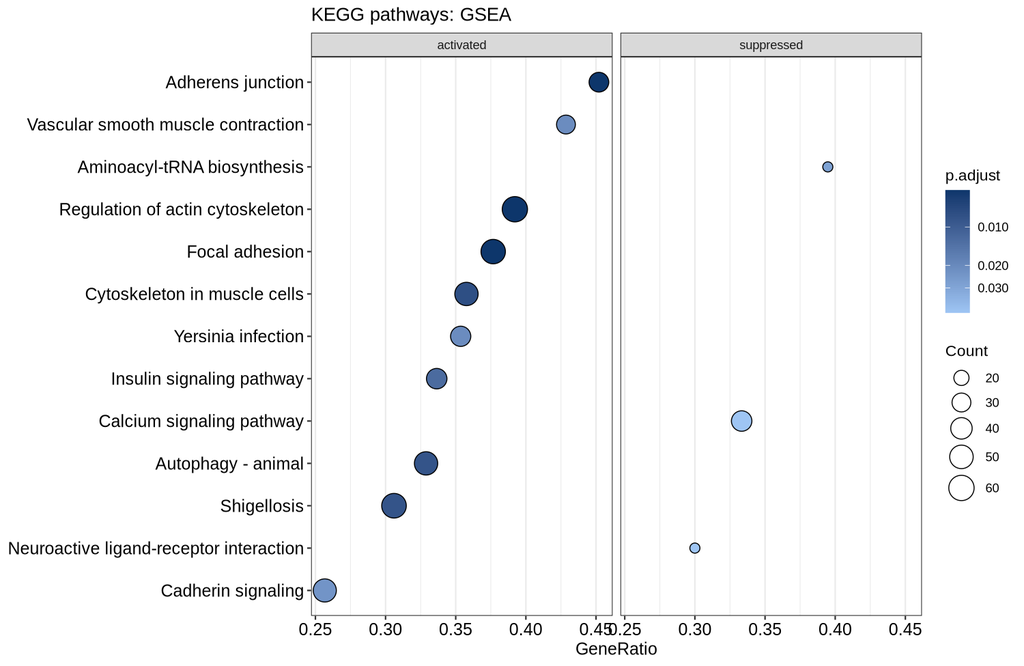